# Tugas 4

G14012110834_Dindana Fitriani

2023-09-21

## White Noise

Pembangkitan data berpola AR, MA, ARMA, dan banyak proses deret waktu lainnya diawali pembangkitan *white noise*. *White noise* merupakan sederet nilai dari peubah bebas stokastik identik. Oleh karena itu, *white noise* memiliki dua karakteristik penting:

1. *White noise* tidak memiliki autokorelasi (**karena saling bebas**)
2. Nilai harapan dan ragam *white noise* sama (**karena berasal dari peubah acak bebas stokastik identik**)

*White noise* dibangkitkan dari suatu peubah acak, umumnya peubah acak normal.

#model Ma2, teta=0,4 teta=0,6

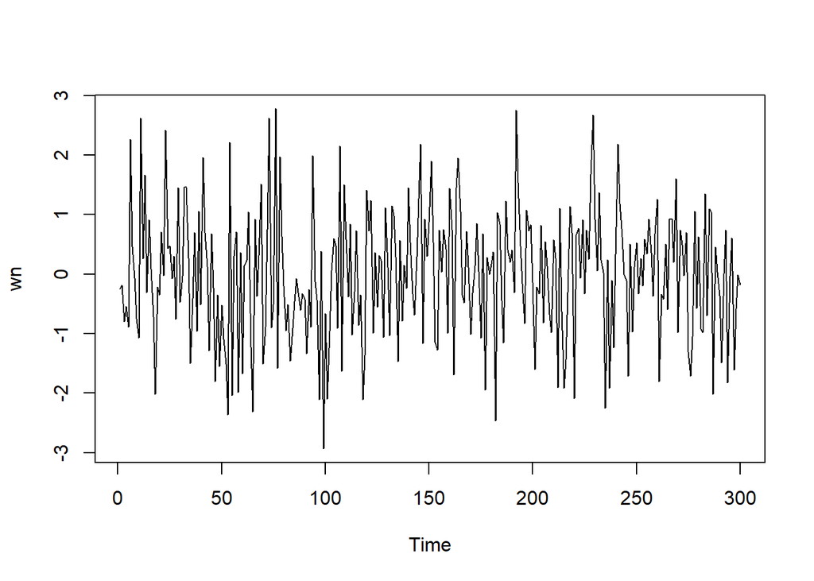

```r
wn <- rnorm(300)
ts.plot(wn)
```

Dapat terlihat bahwa *white noise* tidak memiliki autokorelasi dari ACF. Perhatikan bahwa lag ke-0 adalah korelasi observasi ke-t dengan dirinya sendiri. Nilai korelasi tersebut pasti 1. Sebagai alternatif, lag pertama di plot ACF dapat ditetapkan sebagai 1 (alih-alih 0) dengan menambahkan argumen `xlim(1, lag akhir)`. Plot tersebut dapat disandingkan bersamaan dengan membuat matriks $1 \times 2$ dengan `par(mfrow = c(1,2))`.

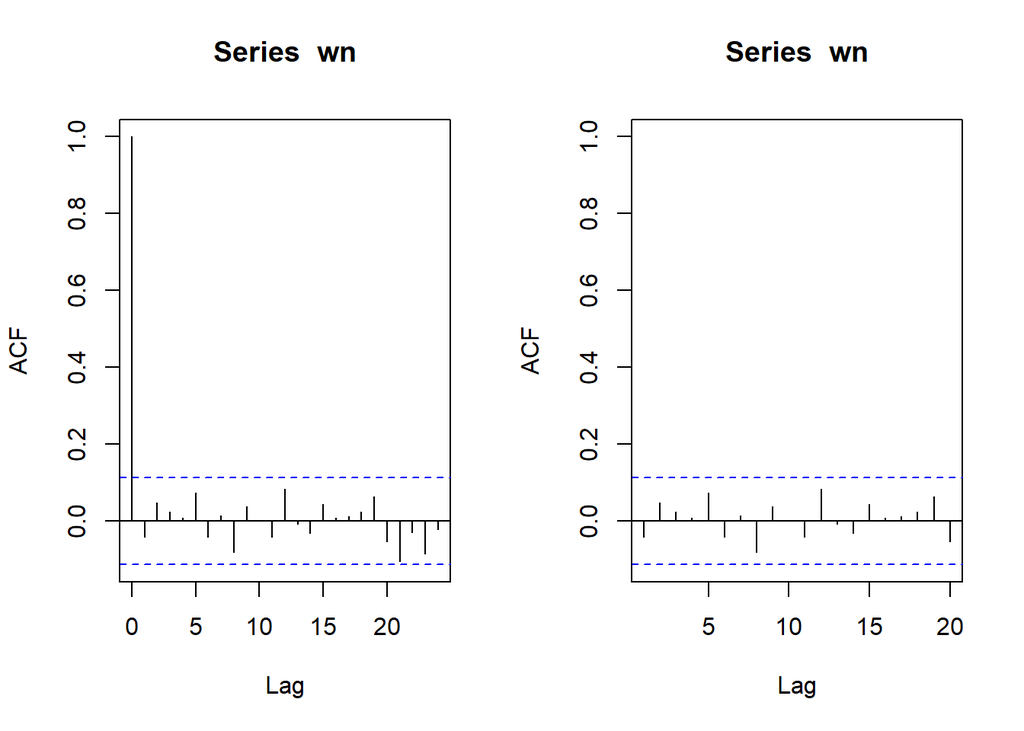

```r
par(mfrow = c(1, 2))
acf(wn)
acf(wn, xlim = c(1, 20))
```

## Proses MA

Proses MA dapat dituliskan sebagai berikut:

$$y_{t} = c + e_t + \theta_{1}e_{t-1} + \theta_{2}e_{t-2} + \dots +
\theta_{q}e_{t-q} = c+{e_t+\sum_{i=1}^p \theta_ie_{t-i}}$$
Terlihat bahwa $e_t$, atau *white noise*, berperan penting dalam pembangkitan proses MA.

Akan dicoba membangkitkan proses MA paling sederhana, yaitu MA(2) dengan $\theta = 0.4$ sebanyak 300 observasi dan $c=0$. Karena diperlukan satu nilai awal untuk $e_{t-1}$ dan $e_{t-2}$. masukkan nilai pertama white noise sebagai nilai awal tersebut.

```r
set.seed(034)
ma <- wn[c(1,2)]
```

$$y_t = e_t+0.4e_{t-1}+0.6e_{t-2}$$

```r
for(i in 3:300){
   ma[i] <- wn[i] + 0.4 * wn[i - 1] +0.6*wn[i - 2]
}
ma
```

```
##   [1] -0.244169996 -0.190067590 -1.012947901 -0.970316226 -1.573706700
##   [6]  1.592722947  0.840147317  1.488363115 -0.492650816 -1.407150534
##  [11]  1.743333986  0.666716235  3.348232125  0.517888129  1.789536567
##  [16]  0.266464852 -0.128173392 -2.251806589 -1.446966829 -1.641746308
##  [21]  0.443325969  0.057757258  2.836440426  1.390964815  2.096942884
##  [26]  0.380632854  0.557911281 -0.673507723  1.329956020 -0.343186690
##  [31]  0.651989791  1.169087805  2.032709514  1.739770321 -0.509881314
##  [36] -0.841741972 -0.359645319 -0.921409471  1.093578169 -0.665143117
##  [41]  2.392060871  1.182042125  1.585089629 -0.812222391  0.245002365
##  [46] -0.722226932 -1.479801219 -1.207388175 -2.771077389 -1.353406547
##  [51] -2.231002762 -2.261360161 -3.624698177  0.359292840 -2.565630615
##  [56]  0.821626103 -0.383353668 -1.519875932 -0.001273431 -2.715835525
##  [61] -0.302619890 -0.710756359  1.227230435 -0.663985370 -2.171331888
##  [66] -0.732205070 -1.388729982  0.721514121  1.419692100 -0.712655617
##  [71] -0.581277893 -0.514706423  2.386835358  0.599137699  0.704645837
```

[output cut: 45 more lines]

```r
ma1 <- arima.sim(list(order=c(0,0,2), ma=c(0.4,0.6)), n=300) #c=ordo , n=observasi
ma1
```

```
## Time Series:
## Start = 1
## End = 300
## Frequency = 1
##   [1] -0.351131226 -0.154449400 -0.942314225 -0.906073661  0.330274277
##   [6] -0.854061893  1.129570682 -0.090147505  0.234218398  0.553479583
##  [11] -0.134143533  1.405632061  0.711696039  2.144606470  0.802535614
##  [16]  0.352106841 -2.018893047 -1.298456401 -2.748263115  1.766001657
##  [21] -0.981930898 -0.329677674 -0.797354198  0.095266767 -0.333914507
##  [26] -0.394827480 -0.980590295  0.769928824 -0.474563038  1.592503716
##  [31] -1.215955684  0.234571970 -0.006023827 -0.212099328  0.415834786
##  [36] -0.168859390  0.251283399  0.060070263 -0.628117484 -0.884950088
##  [41] -2.991209743 -3.086559055 -2.244632412 -0.250180466  0.430702672
##  [46]  2.471104942  0.053125421  1.573404337  0.883830353 -0.230769713
##  [51] -0.566372946 -1.052056565 -1.516210594  0.500637026 -1.258031611
```

[output cut: 49 more lines]

## Karakteristik MA(2)

### Plot Time Series

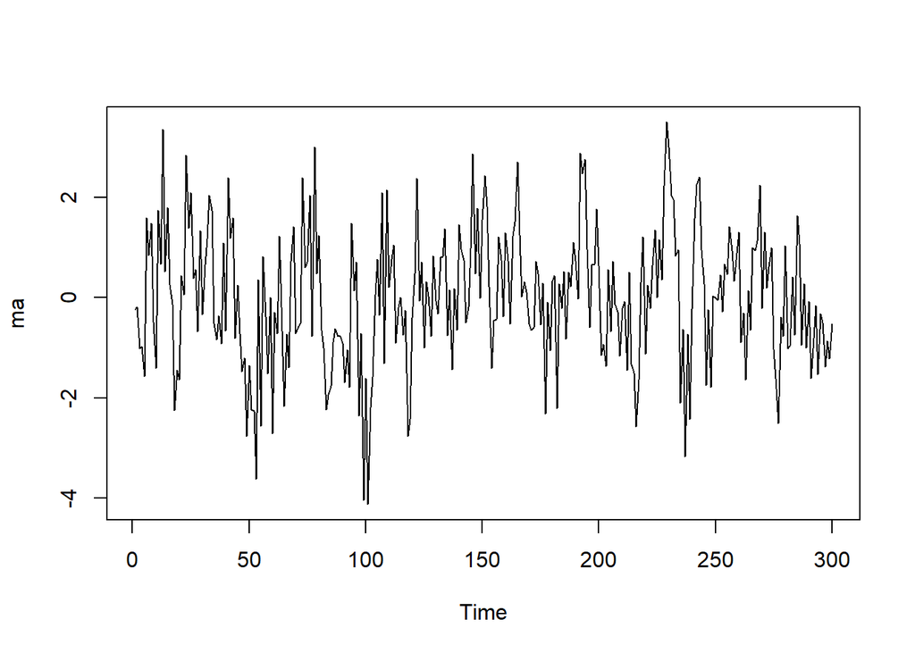

```r
ts.plot(ma)
```

Berdasarkan plot time series, terlihat bahwa data MA(2) yang dibangkitkan stasioner dalam rataan

### Plot ACF =autokorelasi

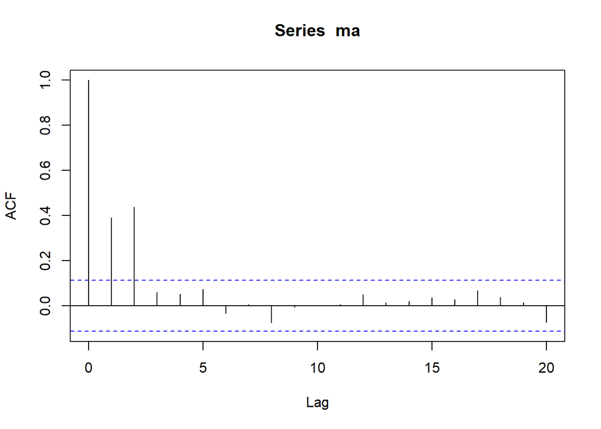

```r
acf(ma,lag.max = 20)
```

Berdasarkan plot AFC tersebut, terlihat bahwa plot ACF *cuts off* di lag kedua.

### Plot PACF

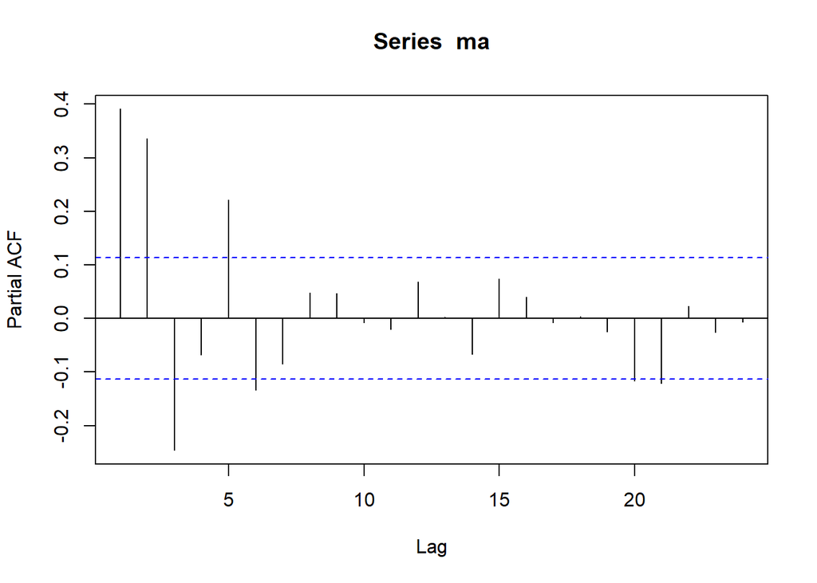

```r
pacf(ma)
```

Berdasarkan plot PACF tersebut, terlihat bahwa plot PACF cenderung *tails off* dan membentuk gelombang sinus

### Plot EACF

```r
TSA::eacf(ma)
```

```
## AR/MA
##   0 1 2 3 4 5 6 7 8 9 10 11 12 13
## 0 x x o o o o o o o o o  o  o  o
## 1 x x x o o o o o o o o  o  o  o
## 2 x x x o o o o o o o o  o  o  o
## 3 x x o o x o o o o o o  o  o  o
## 4 x x x o x x o o o o o  o  o  o
## 5 x x o o x x o o o o o  o  o  o
## 6 x x o o o x o o o o o  o  o  o
## 7 x x x o o x o x o o o  o  o  o
```

### Scatterplot Antar Lag

#### Korelasi antara $Y_t$ dengan $Y_{t-1}$

```r
#Yt
yt_ma <- ma[-1]
yt_ma
```

```
##   [1] -0.190067590 -1.012947901 -0.970316226 -1.573706700  1.592722947
##   [6]  0.840147317  1.488363115 -0.492650816 -1.407150534  1.743333986
##  [11]  0.666716235  3.348232125  0.517888129  1.789536567  0.266464852
##  [16] -0.128173392 -2.251806589 -1.446966829 -1.641746308  0.443325969
##  [21]  0.057757258  2.836440426  1.390964815  2.096942884  0.380632854
##  [26]  0.557911281 -0.673507723  1.329956020 -0.343186690  0.651989791
##  [31]  1.169087805  2.032709514  1.739770321 -0.509881314 -0.841741972
##  [36] -0.359645319 -0.921409471  1.093578169 -0.665143117  2.392060871
##  [41]  1.182042125  1.585089629 -0.812222391  0.245002365 -0.722226932
##  [46] -1.479801219 -1.207388175 -2.771077389 -1.353406547 -2.231002762
##  [51] -2.261360161 -3.624698177  0.359292840 -2.565630615  0.821626103
##  [56] -0.383353668 -1.519875932 -0.001273431 -2.715835525 -0.302619890
##  [61] -0.710756359  1.227230435 -0.663985370 -2.171331888 -0.732205070
##  [66] -1.388729982  0.721514121  1.419692100 -0.712655617 -0.581277893
##  [71] -0.514706423  2.386835358  0.599137699  0.704645837  2.038527768
```

[output cut: 45 more lines]

```r
#Yt-1
yt_1_ma<- ma[-300]
yt_1_ma
```

```
##   [1] -0.244169996 -0.190067590 -1.012947901 -0.970316226 -1.573706700
##   [6]  1.592722947  0.840147317  1.488363115 -0.492650816 -1.407150534
##  [11]  1.743333986  0.666716235  3.348232125  0.517888129  1.789536567
##  [16]  0.266464852 -0.128173392 -2.251806589 -1.446966829 -1.641746308
##  [21]  0.443325969  0.057757258  2.836440426  1.390964815  2.096942884
##  [26]  0.380632854  0.557911281 -0.673507723  1.329956020 -0.343186690
##  [31]  0.651989791  1.169087805  2.032709514  1.739770321 -0.509881314
##  [36] -0.841741972 -0.359645319 -0.921409471  1.093578169 -0.665143117
##  [41]  2.392060871  1.182042125  1.585089629 -0.812222391  0.245002365
##  [46] -0.722226932 -1.479801219 -1.207388175 -2.771077389 -1.353406547
##  [51] -2.231002762 -2.261360161 -3.624698177  0.359292840 -2.565630615
##  [56]  0.821626103 -0.383353668 -1.519875932 -0.001273431 -2.715835525
##  [61] -0.302619890 -0.710756359  1.227230435 -0.663985370 -2.171331888
##  [66] -0.732205070 -1.388729982  0.721514121  1.419692100 -0.712655617
##  [71] -0.581277893 -0.514706423  2.386835358  0.599137699  0.704645837
```

[output cut: 45 more lines]

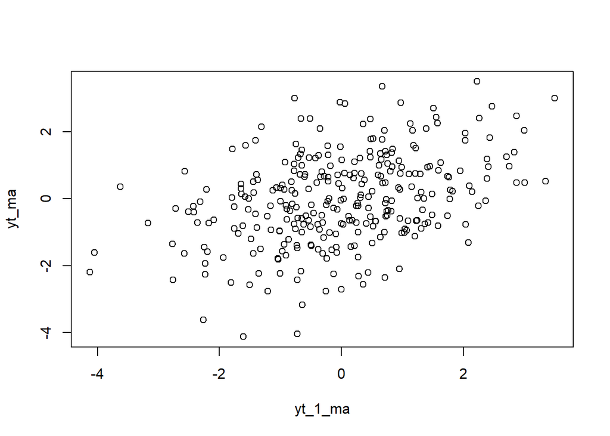

```r
plot(y=yt_ma,x=yt_1_ma)
```

Berdasarkan scatterplot tersebut, terlihat bahwa terdapat hubungan positif antara $Y_t$ dengan $Y_{t-1}$. Hal ini sesuai dengan teori yang ada= cenderung hub.positif

```r
cor(yt_ma,yt_1_ma)
```

```
## [1] 0.3909244
```

Korelasi antara $Y_t$ dengan $Y_{t-1}$ dari hasil simulasi mendekati perhitungan teoritis yaitu

$$\rho_1=\frac{\theta+\theta_1\theta_2}{1+(\theta_1)^2+(\theta_2)^2}=\frac{(0.4)+(0.4*0.6)}{1+(0.4)^2+(0.6)^2}=0.42$$

Tambahan: jika data yg diabngkitkan lebih banyak->semakin mendekati teoritis

#### Korelasi antara $Y_t$ dengan $Y_{t-2}$

```r
#Yt
yt_ma2 <- ma[-c(1,2)]#hilangin data 1,2
yt_ma2
```

```
##   [1] -1.012947901 -0.970316226 -1.573706700  1.592722947  0.840147317
##   [6]  1.488363115 -0.492650816 -1.407150534  1.743333986  0.666716235
##  [11]  3.348232125  0.517888129  1.789536567  0.266464852 -0.128173392
##  [16] -2.251806589 -1.446966829 -1.641746308  0.443325969  0.057757258
##  [21]  2.836440426  1.390964815  2.096942884  0.380632854  0.557911281
##  [26] -0.673507723  1.329956020 -0.343186690  0.651989791  1.169087805
##  [31]  2.032709514  1.739770321 -0.509881314 -0.841741972 -0.359645319
##  [36] -0.921409471  1.093578169 -0.665143117  2.392060871  1.182042125
##  [41]  1.585089629 -0.812222391  0.245002365 -0.722226932 -1.479801219
##  [46] -1.207388175 -2.771077389 -1.353406547 -2.231002762 -2.261360161
##  [51] -3.624698177  0.359292840 -2.565630615  0.821626103 -0.383353668
##  [56] -1.519875932 -0.001273431 -2.715835525 -0.302619890 -0.710756359
##  [61]  1.227230435 -0.663985370 -2.171331888 -0.732205070 -1.388729982
##  [66]  0.721514121  1.419692100 -0.712655617 -0.581277893 -0.514706423
##  [71]  2.386835358  0.599137699  0.704645837  2.038527768 -0.769378769
```

[output cut: 45 more lines]

```r
#Yt-2
yt_2_ma <- ma[-c(299,300)]#hilangin data 199,200
yt_2_ma
```

```
##   [1] -0.244169996 -0.190067590 -1.012947901 -0.970316226 -1.573706700
##   [6]  1.592722947  0.840147317  1.488363115 -0.492650816 -1.407150534
##  [11]  1.743333986  0.666716235  3.348232125  0.517888129  1.789536567
##  [16]  0.266464852 -0.128173392 -2.251806589 -1.446966829 -1.641746308
##  [21]  0.443325969  0.057757258  2.836440426  1.390964815  2.096942884
##  [26]  0.380632854  0.557911281 -0.673507723  1.329956020 -0.343186690
##  [31]  0.651989791  1.169087805  2.032709514  1.739770321 -0.509881314
##  [36] -0.841741972 -0.359645319 -0.921409471  1.093578169 -0.665143117
##  [41]  2.392060871  1.182042125  1.585089629 -0.812222391  0.245002365
##  [46] -0.722226932 -1.479801219 -1.207388175 -2.771077389 -1.353406547
##  [51] -2.231002762 -2.261360161 -3.624698177  0.359292840 -2.565630615
##  [56]  0.821626103 -0.383353668 -1.519875932 -0.001273431 -2.715835525
##  [61] -0.302619890 -0.710756359  1.227230435 -0.663985370 -2.171331888
##  [66] -0.732205070 -1.388729982  0.721514121  1.419692100 -0.712655617
##  [71] -0.581277893 -0.514706423  2.386835358  0.599137699  0.704645837
```

[output cut: 45 more lines]

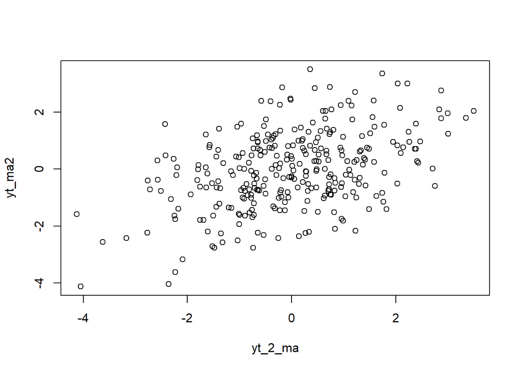

```r
plot(y=yt_ma2,x=yt_2_ma)
```

Berdasarkan scatterplot tersebut, terlihat bahwa cenderung terdapat hubungan antara $Y_t$ dengan $Y_{t-2}$.

```r
cor(yt_ma2,yt_2_ma)
```

```
## [1] 0.4378788
```

```r
#Yt
yt_ma3 <- ma[-c(1,2,3)]
yt_ma3
```

```
##   [1] -0.970316226 -1.573706700  1.592722947  0.840147317  1.488363115
##   [6] -0.492650816 -1.407150534  1.743333986  0.666716235  3.348232125
##  [11]  0.517888129  1.789536567  0.266464852 -0.128173392 -2.251806589
##  [16] -1.446966829 -1.641746308  0.443325969  0.057757258  2.836440426
##  [21]  1.390964815  2.096942884  0.380632854  0.557911281 -0.673507723
##  [26]  1.329956020 -0.343186690  0.651989791  1.169087805  2.032709514
##  [31]  1.739770321 -0.509881314 -0.841741972 -0.359645319 -0.921409471
##  [36]  1.093578169 -0.665143117  2.392060871  1.182042125  1.585089629
##  [41] -0.812222391  0.245002365 -0.722226932 -1.479801219 -1.207388175
##  [46] -2.771077389 -1.353406547 -2.231002762 -2.261360161 -3.624698177
##  [51]  0.359292840 -2.565630615  0.821626103 -0.383353668 -1.519875932
##  [56] -0.001273431 -2.715835525 -0.302619890 -0.710756359  1.227230435
##  [61] -0.663985370 -2.171331888 -0.732205070 -1.388729982  0.721514121
##  [66]  1.419692100 -0.712655617 -0.581277893 -0.514706423  2.386835358
##  [71]  0.599137699  0.704645837  2.038527768 -0.769378769  3.006979850
```

[output cut: 45 more lines]

```r
#Yt-2
yt_3_ma <- ma[-c(298,299,300)]
yt_3_ma
```

```
##   [1] -0.244169996 -0.190067590 -1.012947901 -0.970316226 -1.573706700
##   [6]  1.592722947  0.840147317  1.488363115 -0.492650816 -1.407150534
##  [11]  1.743333986  0.666716235  3.348232125  0.517888129  1.789536567
##  [16]  0.266464852 -0.128173392 -2.251806589 -1.446966829 -1.641746308
##  [21]  0.443325969  0.057757258  2.836440426  1.390964815  2.096942884
##  [26]  0.380632854  0.557911281 -0.673507723  1.329956020 -0.343186690
##  [31]  0.651989791  1.169087805  2.032709514  1.739770321 -0.509881314
##  [36] -0.841741972 -0.359645319 -0.921409471  1.093578169 -0.665143117
##  [41]  2.392060871  1.182042125  1.585089629 -0.812222391  0.245002365
##  [46] -0.722226932 -1.479801219 -1.207388175 -2.771077389 -1.353406547
##  [51] -2.231002762 -2.261360161 -3.624698177  0.359292840 -2.565630615
##  [56]  0.821626103 -0.383353668 -1.519875932 -0.001273431 -2.715835525
##  [61] -0.302619890 -0.710756359  1.227230435 -0.663985370 -2.171331888
##  [66] -0.732205070 -1.388729982  0.721514121  1.419692100 -0.712655617
##  [71] -0.581277893 -0.514706423  2.386835358  0.599137699  0.704645837
```

[output cut: 45 more lines]

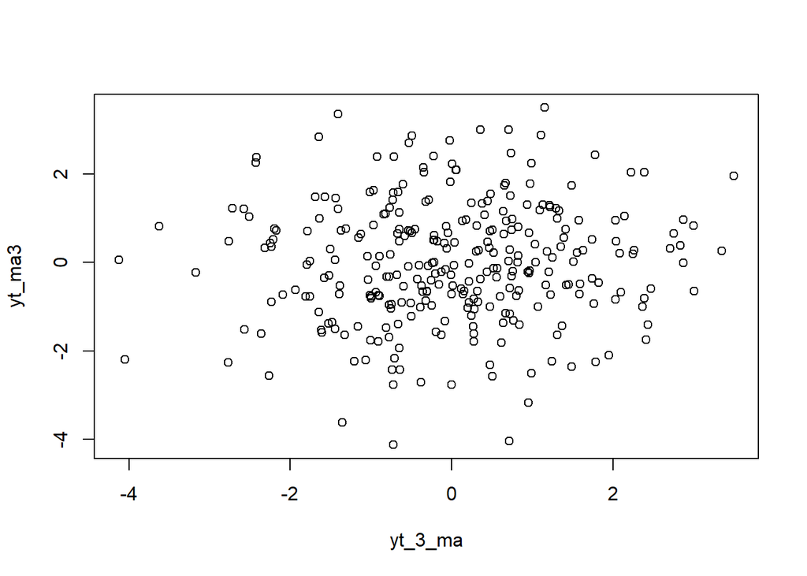

```r
plot(y=yt_ma3,x=yt_3_ma)
```

Berdasarkan scatterplot tersebut, terlihat bahwa cenderung tidak terdapat hubungan antara Yt dengan Yt−3.

```r
cor(yt_ma3,yt_3_ma)
```

```
## [1] 0.05983839
```

Korelasi antara Yt dengan Yt−3 hasil simulasi mendekati teori yang ada yaitu 0.

## Proses AR

Proses AR dapat dituliskan sebagai berikut:

$$y_{t} = c + e_t + \phi_{1}Y_{t-1} +
\phi_{2}Y_{t-2} + \dots + \phi_{q}Y_{t-q} = c+{e_t+\sum_{i=1}^p
\phi_iY_{t-i}}$$
Terlihat bahwa $Y_t$ berperan penting dalam pembangkitan proses AR.

## Pembangkitan Proses AR

Akan dicoba membangkitkan proses AR paling sederhana, yaitu AR(2) dengan $\phi = 0.5$, $\phi = 0.2$ sebanyak 300 observasi dan $c=0$.

```r
set.seed(034)
```

Nilai-nilai selanjutnya dapat dicari melalui *loop*. Bentuk loop dapat dilihat dari rumus AR(2) yang hendak dibangkitkan:

$$Y_t =
e_t+0.5Y_{t-1}+0.2Y_{t-2}$$

```r
n<-length(wn) #panjang white noise
n
```

```
## [1] 300
```

```r
ar <- c(1:n)
for (i in 3:n) {ar[i]<-wn[i]+0.5*ar[i-1]+0.2*ar[i-2]}
ar
```

```
##   [1]  1.00000000  2.00000000  0.40958113  0.06468244 -0.76915468  1.89851182
##   [7]  1.25755850  0.94989971 -0.02003661 -0.89344049  2.16986617  1.16876500
##  [13]  2.68922361  1.27039378  2.08324586  1.38286746  0.39892065 -1.54440733
##  [19] -0.90571256 -1.10590216 -0.02512604 -0.25307457  2.28722985  1.52804656
##  [25]  1.69311811  1.08311375  1.18272431  0.05489243  1.71365780  0.39660949
##  [31]  0.51170522  1.79871348  2.46659036  1.86872778 -0.07141086 -0.06947866
##  [37]  0.65379639 -0.64502289  0.86334541 -0.20969881  2.03176878  1.67782727
##  [43]  1.37043450 -0.26383612  0.82591847  0.13523652 -1.56726685 -1.10897348
##  [49] -2.41802127 -1.95274700 -2.55215515 -3.17795118 -4.46426868 -0.65569239
##  [55] -3.25222618 -1.45023428 -0.66280721 -2.61063883 -1.07113204 -2.72671581
##  [61] -1.43264469 -1.02898450  0.24617307 -1.30518204 -2.91401618 -0.79250265
##  [67] -1.35160542 -0.51909388  0.98727085 -1.11882013 -1.25006240 -0.10307698
##  [73]  2.31986099  0.24245707  0.07574260  2.86678855 -0.12733143  2.47876603
##  [79]  1.84823938  1.22608497  0.03164785 -0.24761824 -1.57461591 -1.88354866
##  [85] -1.71916781 -1.31305857 -1.30704961 -1.52105670 -1.34743964 -1.39530146
```

[output cut: 35 more lines]

Selain menggunakan cara di atas, pembangkitan proses AR dapat dilakukan dengan fungsi `arima.sim()` sebagai berikut.

```r
ar1 <- arima.sim(list(order=c(2,0,0), ar=c(0.5,0.2)), n=300) #?#printing#Ma
ar1
```

```
## Time Series:
## Start = 1
## End = 300
## Frequency = 1
##   [1]  0.182752330 -0.919177412 -0.926907469 -0.886663155  0.539286866
##   [6] -0.705827848  0.965902663 -0.879670418 -0.250075762  0.427246350
##  [11] -0.337725980  0.096023679  0.040632695  0.159075623  0.063813166
##  [16] -0.626588026 -0.895046864 -2.912058746 -3.429201427 -2.420449177
##  [21] -1.020373046 -0.839788389  1.259925854 -0.331119975  0.846742815
##  [26]  1.412725848 -0.233480179 -0.590238260 -0.425939395 -1.359952248
##  [31]  0.197521519 -1.198974571  0.704460659  0.105777160  1.427895449
##  [36] -0.292147870  1.542550514 -0.596298251 -1.778438007 -1.732934959
##  [41] -0.917318454  0.036964169  0.515911324  0.935816331  0.091515211
##  [46]  0.733793089 -0.414941372 -0.587949626  1.995852339  0.457037366
##  [51] -0.466907163 -0.203015851 -1.722698711 -2.317144597 -0.768307625
```

[output cut: 49 more lines]

## Karakteristik AR(2)

### Plot Time Series

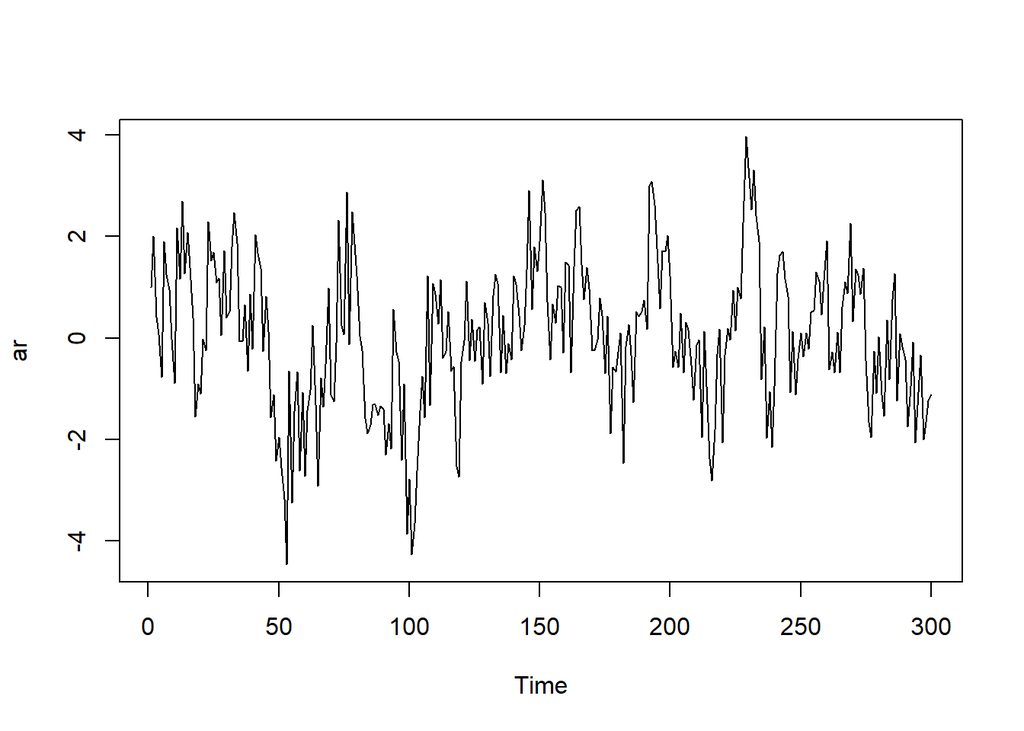

```r
ts.plot(ar)
```

Berdasarkan plot time series tersebut terlihat bahwa data cenderung stasioner pada rataan

### Plot ACF

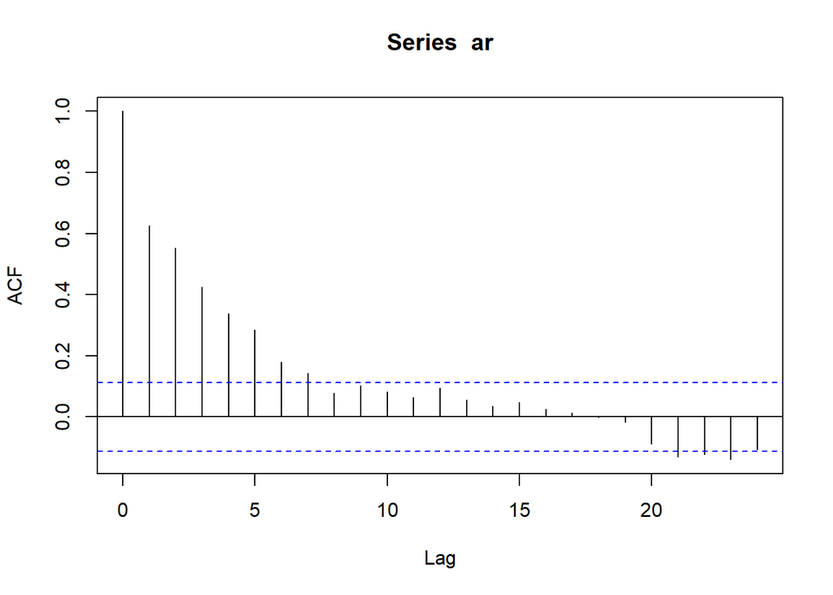

```r
acf(ar)
```

Berdasarkan plot ACF tersebut terlihat bahwa plot ACF cenderung *tails off* (turun perlahan) dan cenderung membentuk pola grafik cosinus

### Plot PACF

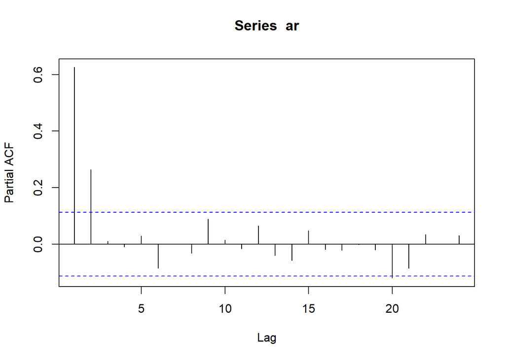

```r
pacf(ar)
```

Berdasarkan plot PACF tersebut, terlihat bahwa plot PACF *cuts off* pada lag pertama,kedua sejalan dengan teori yang ada Ma=acf yg cut off

### Plot EACF

```r
TSA::eacf(ar)
```

```
## AR/MA
##   0 1 2 3 4 5 6 7 8 9 10 11 12 13
## 0 x x x x x x x o o o o  o  o  o
## 1 x o o o o o o o o o o  o  o  o
## 2 o o o o o o o o o o o  o  o  o
## 3 x o o o o o o o o o o  o  o  o
## 4 x o o x o o o o o o o  o  o  o
## 5 x o x o o o o o o o o  o  o  o
## 6 o x x o o o o o o o o  o  o  o
## 7 x o x o o o o o o o o  o  o  o
```

Berdasarkan pola segitiga nol pada plot EACF, terlihat bahwa segitiga nol berada pada ordo AR(1) dan ordo MA(1)

### Scatterplot Antar Lag

#### Korelasi antara $Y_t$ dengan $Y_{t-1}$

#Yt

```r
yt_ar <- ar[-1] #yt dikurang 1
yt_ar
```

```
##   [1]  2.00000000  0.40958113  0.06468244 -0.76915468  1.89851182  1.25755850
##   [7]  0.94989971 -0.02003661 -0.89344049  2.16986617  1.16876500  2.68922361
##  [13]  1.27039378  2.08324586  1.38286746  0.39892065 -1.54440733 -0.90571256
##  [19] -1.10590216 -0.02512604 -0.25307457  2.28722985  1.52804656  1.69311811
##  [25]  1.08311375  1.18272431  0.05489243  1.71365780  0.39660949  0.51170522
##  [31]  1.79871348  2.46659036  1.86872778 -0.07141086 -0.06947866  0.65379639
##  [37] -0.64502289  0.86334541 -0.20969881  2.03176878  1.67782727  1.37043450
##  [43] -0.26383612  0.82591847  0.13523652 -1.56726685 -1.10897348 -2.41802127
##  [49] -1.95274700 -2.55215515 -3.17795118 -4.46426868 -0.65569239 -3.25222618
##  [55] -1.45023428 -0.66280721 -2.61063883 -1.07113204 -2.72671581 -1.43264469
##  [61] -1.02898450  0.24617307 -1.30518204 -2.91401618 -0.79250265 -1.35160542
##  [67] -0.51909388  0.98727085 -1.11882013 -1.25006240 -0.10307698  2.31986099
##  [73]  0.24245707  0.07574260  2.86678855 -0.12733143  2.47876603  1.84823938
##  [79]  1.22608497  0.03164785 -0.24761824 -1.57461591 -1.88354866 -1.71916781
##  [85] -1.31305857 -1.30704961 -1.52105670 -1.34743964 -1.39530146 -2.29794141
```

[output cut: 35 more lines]

```r
#Yt-1
yt_1_ar<- ar[-300]
yt_1_ar
```

```
##   [1]  1.00000000  2.00000000  0.40958113  0.06468244 -0.76915468  1.89851182
##   [7]  1.25755850  0.94989971 -0.02003661 -0.89344049  2.16986617  1.16876500
##  [13]  2.68922361  1.27039378  2.08324586  1.38286746  0.39892065 -1.54440733
##  [19] -0.90571256 -1.10590216 -0.02512604 -0.25307457  2.28722985  1.52804656
##  [25]  1.69311811  1.08311375  1.18272431  0.05489243  1.71365780  0.39660949
##  [31]  0.51170522  1.79871348  2.46659036  1.86872778 -0.07141086 -0.06947866
##  [37]  0.65379639 -0.64502289  0.86334541 -0.20969881  2.03176878  1.67782727
##  [43]  1.37043450 -0.26383612  0.82591847  0.13523652 -1.56726685 -1.10897348
##  [49] -2.41802127 -1.95274700 -2.55215515 -3.17795118 -4.46426868 -0.65569239
##  [55] -3.25222618 -1.45023428 -0.66280721 -2.61063883 -1.07113204 -2.72671581
##  [61] -1.43264469 -1.02898450  0.24617307 -1.30518204 -2.91401618 -0.79250265
##  [67] -1.35160542 -0.51909388  0.98727085 -1.11882013 -1.25006240 -0.10307698
##  [73]  2.31986099  0.24245707  0.07574260  2.86678855 -0.12733143  2.47876603
##  [79]  1.84823938  1.22608497  0.03164785 -0.24761824 -1.57461591 -1.88354866
##  [85] -1.71916781 -1.31305857 -1.30704961 -1.52105670 -1.34743964 -1.39530146
```

[output cut: 35 more lines]

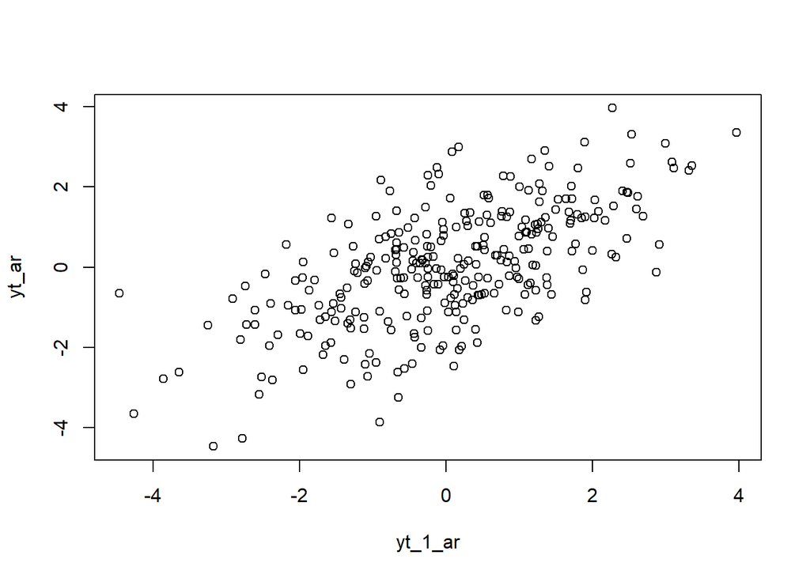

```r
plot(y=yt_ar,x=yt_1_ar)
```

```r
cor(yt_ar,yt_1_ar)
```

```
## [1] 0.6268854
```

#### Korelasi antara $Y_t$ dengan $Y_{t-2}$

```r
#Yt
yt_ar2 <- ar[-c(1,2)]#karena yt-2 kurangin 2 data terkahir
yt_ar2
```

```
##   [1]  0.40958113  0.06468244 -0.76915468  1.89851182  1.25755850  0.94989971
##   [7] -0.02003661 -0.89344049  2.16986617  1.16876500  2.68922361  1.27039378
##  [13]  2.08324586  1.38286746  0.39892065 -1.54440733 -0.90571256 -1.10590216
##  [19] -0.02512604 -0.25307457  2.28722985  1.52804656  1.69311811  1.08311375
##  [25]  1.18272431  0.05489243  1.71365780  0.39660949  0.51170522  1.79871348
##  [31]  2.46659036  1.86872778 -0.07141086 -0.06947866  0.65379639 -0.64502289
##  [37]  0.86334541 -0.20969881  2.03176878  1.67782727  1.37043450 -0.26383612
##  [43]  0.82591847  0.13523652 -1.56726685 -1.10897348 -2.41802127 -1.95274700
##  [49] -2.55215515 -3.17795118 -4.46426868 -0.65569239 -3.25222618 -1.45023428
##  [55] -0.66280721 -2.61063883 -1.07113204 -2.72671581 -1.43264469 -1.02898450
##  [61]  0.24617307 -1.30518204 -2.91401618 -0.79250265 -1.35160542 -0.51909388
##  [67]  0.98727085 -1.11882013 -1.25006240 -0.10307698  2.31986099  0.24245707
##  [73]  0.07574260  2.86678855 -0.12733143  2.47876603  1.84823938  1.22608497
##  [79]  0.03164785 -0.24761824 -1.57461591 -1.88354866 -1.71916781 -1.31305857
##  [85] -1.30704961 -1.52105670 -1.34743964 -1.39530146 -2.29794141 -1.68397271
```

[output cut: 35 more lines]

```r
#Yt-2
yt_2_ar <- ar[-c(299,300)]
yt_2_ar
```

```
##   [1]  1.00000000  2.00000000  0.40958113  0.06468244 -0.76915468  1.89851182
##   [7]  1.25755850  0.94989971 -0.02003661 -0.89344049  2.16986617  1.16876500
##  [13]  2.68922361  1.27039378  2.08324586  1.38286746  0.39892065 -1.54440733
##  [19] -0.90571256 -1.10590216 -0.02512604 -0.25307457  2.28722985  1.52804656
##  [25]  1.69311811  1.08311375  1.18272431  0.05489243  1.71365780  0.39660949
##  [31]  0.51170522  1.79871348  2.46659036  1.86872778 -0.07141086 -0.06947866
##  [37]  0.65379639 -0.64502289  0.86334541 -0.20969881  2.03176878  1.67782727
##  [43]  1.37043450 -0.26383612  0.82591847  0.13523652 -1.56726685 -1.10897348
##  [49] -2.41802127 -1.95274700 -2.55215515 -3.17795118 -4.46426868 -0.65569239
##  [55] -3.25222618 -1.45023428 -0.66280721 -2.61063883 -1.07113204 -2.72671581
##  [61] -1.43264469 -1.02898450  0.24617307 -1.30518204 -2.91401618 -0.79250265
##  [67] -1.35160542 -0.51909388  0.98727085 -1.11882013 -1.25006240 -0.10307698
##  [73]  2.31986099  0.24245707  0.07574260  2.86678855 -0.12733143  2.47876603
##  [79]  1.84823938  1.22608497  0.03164785 -0.24761824 -1.57461591 -1.88354866
##  [85] -1.71916781 -1.31305857 -1.30704961 -1.52105670 -1.34743964 -1.39530146
```

[output cut: 35 more lines]

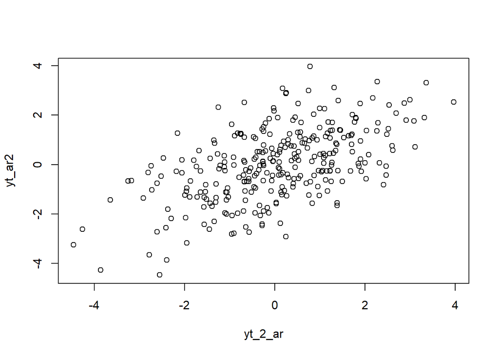

```r
plot(y=yt_ar2,x=yt_2_ar)
```

Berdasarkan scatterplot tersebut, terlihat bahwa terdapat hubungan positif antara $Y_t$ dengan $Y_{t-2}$. Hal ini sesuai dengan teori yang ada

```r
cor(yt_ar2,yt_2_ar)
```

```
## [1] 0.5553496
```

misal ar=0,7 maka jadi 0,7^3

Korelasi antara $Y_t$ dengan $Y_{t-2}$ dari hasil simulasi mendekati perhitungan teoritis yaitu $\rho_2=\phi_1^2/1-\phi_2=0.5125$.

#### Korelasi antara $Y_t$ dengan $Y_{t-3}$

```r
#Yt
yt_ar3 <- ar[-c(1,2,3)]#karena yt-2 kurangin 2 data terkahir
yt_ar3
```

```
##   [1]  0.06468244 -0.76915468  1.89851182  1.25755850  0.94989971 -0.02003661
##   [7] -0.89344049  2.16986617  1.16876500  2.68922361  1.27039378  2.08324586
##  [13]  1.38286746  0.39892065 -1.54440733 -0.90571256 -1.10590216 -0.02512604
##  [19] -0.25307457  2.28722985  1.52804656  1.69311811  1.08311375  1.18272431
##  [25]  0.05489243  1.71365780  0.39660949  0.51170522  1.79871348  2.46659036
##  [31]  1.86872778 -0.07141086 -0.06947866  0.65379639 -0.64502289  0.86334541
##  [37] -0.20969881  2.03176878  1.67782727  1.37043450 -0.26383612  0.82591847
##  [43]  0.13523652 -1.56726685 -1.10897348 -2.41802127 -1.95274700 -2.55215515
##  [49] -3.17795118 -4.46426868 -0.65569239 -3.25222618 -1.45023428 -0.66280721
##  [55] -2.61063883 -1.07113204 -2.72671581 -1.43264469 -1.02898450  0.24617307
##  [61] -1.30518204 -2.91401618 -0.79250265 -1.35160542 -0.51909388  0.98727085
##  [67] -1.11882013 -1.25006240 -0.10307698  2.31986099  0.24245707  0.07574260
##  [73]  2.86678855 -0.12733143  2.47876603  1.84823938  1.22608497  0.03164785
##  [79] -0.24761824 -1.57461591 -1.88354866 -1.71916781 -1.31305857 -1.30704961
##  [85] -1.52105670 -1.34743964 -1.39530146 -2.29794141 -1.68397271 -2.18462067
```

[output cut: 35 more lines]

```r
#Yt-3
yt_3_ar <- ar[-c(288,299,300)] #hilangin data akhir
yt_3_ar
```

```
##   [1]  1.00000000  2.00000000  0.40958113  0.06468244 -0.76915468  1.89851182
##   [7]  1.25755850  0.94989971 -0.02003661 -0.89344049  2.16986617  1.16876500
##  [13]  2.68922361  1.27039378  2.08324586  1.38286746  0.39892065 -1.54440733
##  [19] -0.90571256 -1.10590216 -0.02512604 -0.25307457  2.28722985  1.52804656
##  [25]  1.69311811  1.08311375  1.18272431  0.05489243  1.71365780  0.39660949
##  [31]  0.51170522  1.79871348  2.46659036  1.86872778 -0.07141086 -0.06947866
##  [37]  0.65379639 -0.64502289  0.86334541 -0.20969881  2.03176878  1.67782727
##  [43]  1.37043450 -0.26383612  0.82591847  0.13523652 -1.56726685 -1.10897348
##  [49] -2.41802127 -1.95274700 -2.55215515 -3.17795118 -4.46426868 -0.65569239
##  [55] -3.25222618 -1.45023428 -0.66280721 -2.61063883 -1.07113204 -2.72671581
##  [61] -1.43264469 -1.02898450  0.24617307 -1.30518204 -2.91401618 -0.79250265
##  [67] -1.35160542 -0.51909388  0.98727085 -1.11882013 -1.25006240 -0.10307698
##  [73]  2.31986099  0.24245707  0.07574260  2.86678855 -0.12733143  2.47876603
##  [79]  1.84823938  1.22608497  0.03164785 -0.24761824 -1.57461591 -1.88354866
##  [85] -1.71916781 -1.31305857 -1.30704961 -1.52105670 -1.34743964 -1.39530146
```

[output cut: 35 more lines]

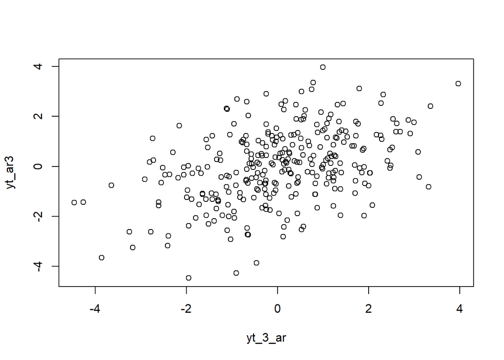

```r
plot(y=yt_ar3,x=yt_3_ar)
```

```r
#Autokorelasi
cor(yt_ar3,yt_3_ar)
```

```
## [1] 0.4235367
```

Korelasi antara $Y_t$ dengan $Y_{t-3}$ dari hasil simulasi mendekati perhitungan teoritis yaitu $\rho_2=\phi_1^2+\phi_1\phi_2/1-\phi_2+\phi_1\phi_2=0.38125$.

## Fungsi pembangkitan ARMA

bentuk umum data berpola ARMA.

$$y_{t} = c + \sum_{i=1}^p \phi_{i}y_{t-i} + \sum_{j=1}^q e_{t-j}+ e_{t}$$

```r
set.seed(034)
n = length(wn)
phi1 = 0.5
phi2 = 0.2

theta1 = 0.4
theta2 = 0.6

y.arma=c(1:n)
for (i in 5:n){y.arma[i] = phi1*y.arma[i-1] +phi2*y.arma[i-2] + theta1*wn[i-1] + phi2*y.arma[i-2]+wn[i]}
y.arma
```

```
##   [1]  1.00000000  2.00000000  3.00000000  4.00000000  2.10054462  4.56706013
##   [7]  4.49394251  4.20006682  3.12767948  1.87186507  4.37823722  4.24862215
##  [13]  5.65148184  4.88556590  5.49039153  5.15066959  4.09719546  1.80475952
##  [19]  1.51978847  1.05231642  1.70537538  1.53787016  3.86214513  3.94878412
##  [25]  4.16491759  3.78157737  3.83167768  2.79639484  4.07929822  3.26687584
##  [31]  3.04734697  4.28223036  5.41036213  5.27972015  3.41518807  2.81232618
##  [37]  3.31204869  2.10405662  3.04873522  2.27566235  4.11632759  4.45789102
##  [43]  4.28219672  2.68970279  3.22763218  2.73824157  0.77012266  0.40794307
##  [49] -1.17901551 -1.56830465 -2.55671259 -3.85387332 -5.91901344 -3.23496868
##  [55] -5.13180310 -4.36548223 -3.39990027 -5.15022934 -4.36400131 -5.76441489
##  [61] -5.15047715 -4.59034767 -3.21509804 -4.24728206 -6.20932869 -4.80229923
##  [67] -4.88721521 -4.19833828 -2.41083261 -3.78653285 -4.34916069 -3.29871784
##  [73] -0.46932393 -1.40244235 -1.75715209  1.13708960 -0.59801993  1.49455022
##  [79]  1.93001941  1.62277093  0.55483554  0.03744998 -1.41994081 -2.32456202
##  [85] -2.61141446 -2.49728509 -2.63060106 -3.04180945 -3.14061459 -3.33460193
```

[output cut: 35 more lines]

#Pembangkitan Proses ARMA(2,2) manual dengan fungsi arima.sim

```r
arma22 <- arima.sim(list(order=c(2,0,2), ar = c(0.5,0.2), ma =c(0.4,0.6)), n=300)
arma22
```

```
## Time Series:
## Start = 1
## End = 300
## Frequency = 1
##   [1] -1.185593674 -1.809440801 -0.371910311 -1.022406354  1.006918477
##   [6] -0.916977716 -0.022533192 -0.200685967 -0.316948950  0.217223118
##  [11] -0.123637621  0.232909212  0.151797345 -0.505636969 -1.107409104
##  [16] -3.646041688 -5.131061720 -5.539371609 -4.046078615 -2.700210957
##  [21]  0.311783741 -0.331024900  1.470248635  1.552749691  0.839654859
##  [26]  0.164004422 -0.802123382 -1.884471401 -0.602023351 -1.935937567
##  [31]  0.343383548 -0.331823467  1.892882595  0.342476519  2.282428570
##  [36] -0.154566818 -1.091427037 -2.802089142 -2.677555264 -1.369724205
##  [41] -0.019694094  1.164359352  0.775388530  1.331888966 -0.066515014
##  [46] -0.313650324  1.511707663  0.902608524  0.913419186 -0.115556298
##  [51] -2.084049350 -3.128033593 -2.728784691 -2.161585080  0.245385588
```

[output cut: 49 more lines]

#Karakteristik ARMA(2,2)

#Plot Time Series

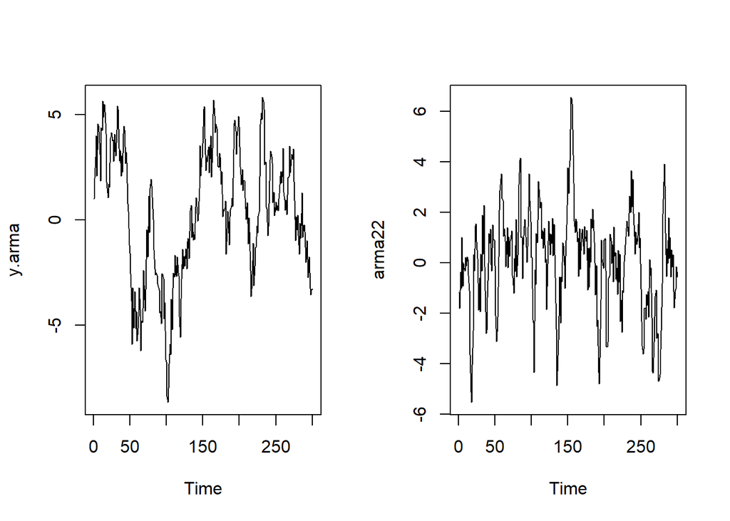

```r
par(mfrow = c(1, 2))
ts.plot(y.arma)
ts.plot(arma22)
```

```r
par(mfrow = c(1, 1))
```

#Plot ACF

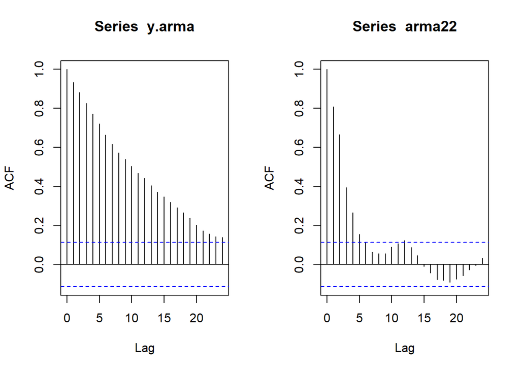

```r
par(mfrow = c(1, 2))
acf(y.arma)
acf(arma22)
```

```r
par(mfrow = c(1, 1))
```

Berdasarkan plot ACF tersebut, terlihat bahwa model ARMA(2,2) hasil simulasi memiliki plot ACF yang tails off, sesuai dengan teori yang ada.

#Plot PACF

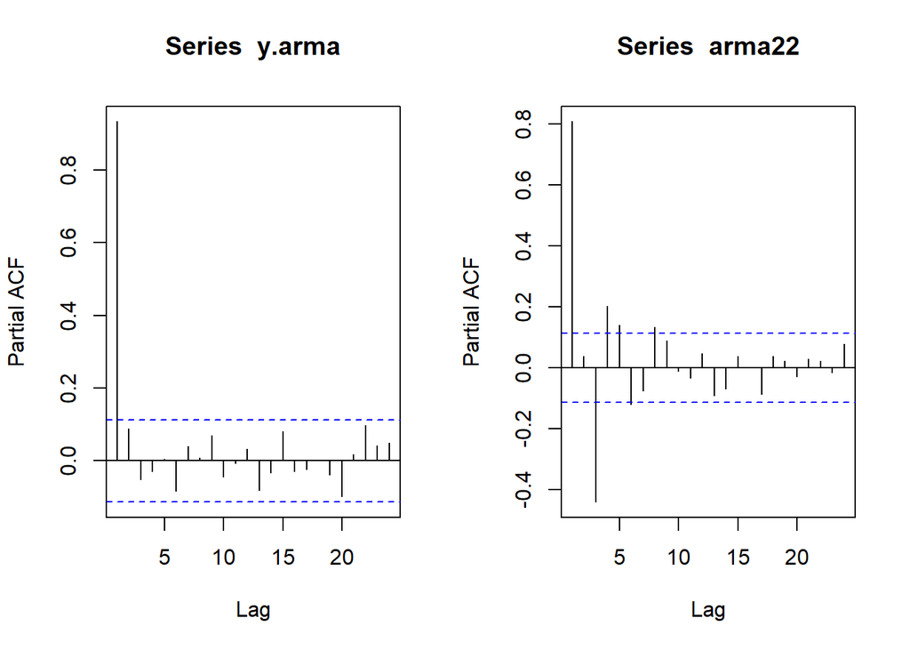

```r
par(mfrow = c(1, 2))
pacf(y.arma)
pacf(arma22)
```

```r
par(mfrow = c(1, 1))
```

#Plot EACF

```r
TSA::eacf(y.arma)
```

```
## AR/MA
##   0 1 2 3 4 5 6 7 8 9 10 11 12 13
## 0 x x x x x x x x x x x  x  x  x
## 1 o o o o o o o o o o o  o  o  o
## 2 x o o o o o o o o o o  o  o  o
## 3 x o o o o o o o o o o  o  o  o
## 4 x o o o o o o o o o o  o  o  o
## 5 x x x x o o o o o o o  o  o  o
## 6 x x x x x o o o o o o  o  o  o
## 7 o x x x o x o o o o o  o  o  o
```

```r
TSA::eacf(arma22)
```

```
## AR/MA
##   0 1 2 3 4 5 6 7 8 9 10 11 12 13
## 0 x x x x x o o o o o o  x  o  o
## 1 o x x o x o o o o o o  x  o  o
## 2 o x x o o o o o o o o  x  o  o
## 3 x x x x o o o o o o o  o  o  o
## 4 x x x x o o o x o o o  o  o  o
## 5 x x x o o o o o o o o  o  o  o
## 6 x x x o o o o o o o o  o  o  o
## 7 x x x x x o o x o o o  o  o  o
```

Berdasarkan pola segitiga nol pada plot EACF, terlihat bahwa segitiga nol berada pada ordo AR(1) dan ordo MA(0).

#Scatterplot Antar Lag #Korelasi antara Yt dengan Yt−1

```r
#Yt
yt_arma <- arma22[-1]
yt_arma
```

```
##   [1] -1.809440801 -0.371910311 -1.022406354  1.006918477 -0.916977716
##   [6] -0.022533192 -0.200685967 -0.316948950  0.217223118 -0.123637621
##  [11]  0.232909212  0.151797345 -0.505636969 -1.107409104 -3.646041688
##  [16] -5.131061720 -5.539371609 -4.046078615 -2.700210957  0.311783741
##  [21] -0.331024900  1.470248635  1.552749691  0.839654859  0.164004422
##  [26] -0.802123382 -1.884471401 -0.602023351 -1.935937567  0.343383548
##  [31] -0.331823467  1.892882595  0.342476519  2.282428570 -0.154566818
##  [36] -1.091427037 -2.802089142 -2.677555264 -1.369724205 -0.019694094
##  [41]  1.164359352  0.775388530  1.331888966 -0.066515014 -0.313650324
##  [46]  1.511707663  0.902608524  0.913419186 -0.115556298 -2.084049350
##  [51] -3.128033593 -2.728784691 -2.161585080  0.245385588  2.095931162
##  [56]  2.857417390  3.326650995  3.533892066  2.570620250  2.468867420
##  [61]  1.048589050  1.345820994  0.867908189 -0.149646695  0.325999095
##  [66]  1.394943551 -0.197430390  1.039989055  0.252040089  0.858289930
##  [71]  0.920055785  1.276532497 -0.505572106 -0.583755239 -1.199092245
```

[output cut: 45 more lines]

```r
#Yt-1
yt_1_arma <- arma22[-300]
yt_1_arma
```

```
##   [1] -1.185593674 -1.809440801 -0.371910311 -1.022406354  1.006918477
##   [6] -0.916977716 -0.022533192 -0.200685967 -0.316948950  0.217223118
##  [11] -0.123637621  0.232909212  0.151797345 -0.505636969 -1.107409104
##  [16] -3.646041688 -5.131061720 -5.539371609 -4.046078615 -2.700210957
##  [21]  0.311783741 -0.331024900  1.470248635  1.552749691  0.839654859
##  [26]  0.164004422 -0.802123382 -1.884471401 -0.602023351 -1.935937567
##  [31]  0.343383548 -0.331823467  1.892882595  0.342476519  2.282428570
##  [36] -0.154566818 -1.091427037 -2.802089142 -2.677555264 -1.369724205
##  [41] -0.019694094  1.164359352  0.775388530  1.331888966 -0.066515014
##  [46] -0.313650324  1.511707663  0.902608524  0.913419186 -0.115556298
##  [51] -2.084049350 -3.128033593 -2.728784691 -2.161585080  0.245385588
##  [56]  2.095931162  2.857417390  3.326650995  3.533892066  2.570620250
##  [61]  2.468867420  1.048589050  1.345820994  0.867908189 -0.149646695
##  [66]  0.325999095  1.394943551 -0.197430390  1.039989055  0.252040089
##  [71]  0.858289930  0.920055785  1.276532497 -0.505572106 -0.583755239
```

[output cut: 45 more lines]

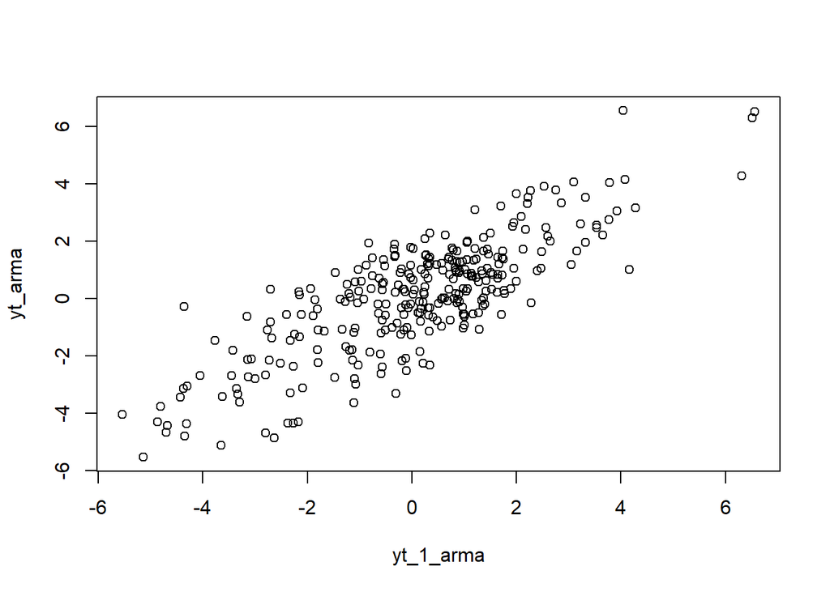

```r
plot(y=yt_arma,x=yt_1_arma)
```

```r
cor(yt_arma,yt_1_arma)
```

```
## [1] 0.8083377
```

#Korelasi antara Yt dengan Yt−2

```r
#Yt
yt_arma2 <- arma22[-c(1,2)]
yt_arma2
```

```
##   [1] -0.371910311 -1.022406354  1.006918477 -0.916977716 -0.022533192
##   [6] -0.200685967 -0.316948950  0.217223118 -0.123637621  0.232909212
##  [11]  0.151797345 -0.505636969 -1.107409104 -3.646041688 -5.131061720
##  [16] -5.539371609 -4.046078615 -2.700210957  0.311783741 -0.331024900
##  [21]  1.470248635  1.552749691  0.839654859  0.164004422 -0.802123382
##  [26] -1.884471401 -0.602023351 -1.935937567  0.343383548 -0.331823467
##  [31]  1.892882595  0.342476519  2.282428570 -0.154566818 -1.091427037
##  [36] -2.802089142 -2.677555264 -1.369724205 -0.019694094  1.164359352
##  [41]  0.775388530  1.331888966 -0.066515014 -0.313650324  1.511707663
##  [46]  0.902608524  0.913419186 -0.115556298 -2.084049350 -3.128033593
##  [51] -2.728784691 -2.161585080  0.245385588  2.095931162  2.857417390
##  [56]  3.326650995  3.533892066  2.570620250  2.468867420  1.048589050
##  [61]  1.345820994  0.867908189 -0.149646695  0.325999095  1.394943551
##  [66] -0.197430390  1.039989055  0.252040089  0.858289930  0.920055785
##  [71]  1.276532497 -0.505572106 -0.583755239 -1.199092245  0.177857517
```

[output cut: 45 more lines]

```r
#Yt-2
yt_2_arma <- arma22[-c(299,300)]
yt_2_arma
```

```
##   [1] -1.185593674 -1.809440801 -0.371910311 -1.022406354  1.006918477
##   [6] -0.916977716 -0.022533192 -0.200685967 -0.316948950  0.217223118
##  [11] -0.123637621  0.232909212  0.151797345 -0.505636969 -1.107409104
##  [16] -3.646041688 -5.131061720 -5.539371609 -4.046078615 -2.700210957
##  [21]  0.311783741 -0.331024900  1.470248635  1.552749691  0.839654859
##  [26]  0.164004422 -0.802123382 -1.884471401 -0.602023351 -1.935937567
##  [31]  0.343383548 -0.331823467  1.892882595  0.342476519  2.282428570
##  [36] -0.154566818 -1.091427037 -2.802089142 -2.677555264 -1.369724205
##  [41] -0.019694094  1.164359352  0.775388530  1.331888966 -0.066515014
##  [46] -0.313650324  1.511707663  0.902608524  0.913419186 -0.115556298
##  [51] -2.084049350 -3.128033593 -2.728784691 -2.161585080  0.245385588
##  [56]  2.095931162  2.857417390  3.326650995  3.533892066  2.570620250
##  [61]  2.468867420  1.048589050  1.345820994  0.867908189 -0.149646695
##  [66]  0.325999095  1.394943551 -0.197430390  1.039989055  0.252040089
##  [71]  0.858289930  0.920055785  1.276532497 -0.505572106 -0.583755239
```

[output cut: 45 more lines]

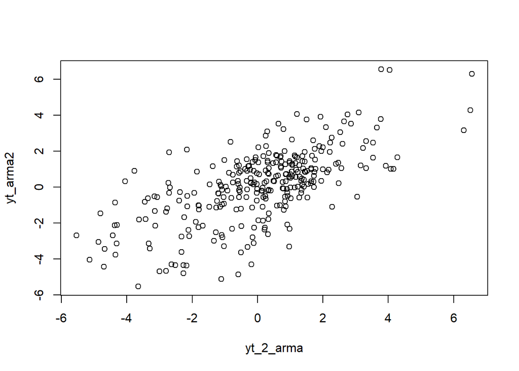

```r
plot(y=yt_arma2,x=yt_2_arma)
```

Berdasarkan scatterplot tersebut, terlihat bahwa terdapat hubungan positif antara Yt dengan Yt−2.

```r
cor(yt_arma2,yt_2_arma)
```

```
## [1] 0.6665491
```

#Korelasi antara Yt dengan Yt−3

```r
#Yt
yt_arma3 <- arma22[-c(1,2,3)]
yt_arma3
```

```
##   [1] -1.022406354  1.006918477 -0.916977716 -0.022533192 -0.200685967
##   [6] -0.316948950  0.217223118 -0.123637621  0.232909212  0.151797345
##  [11] -0.505636969 -1.107409104 -3.646041688 -5.131061720 -5.539371609
##  [16] -4.046078615 -2.700210957  0.311783741 -0.331024900  1.470248635
##  [21]  1.552749691  0.839654859  0.164004422 -0.802123382 -1.884471401
##  [26] -0.602023351 -1.935937567  0.343383548 -0.331823467  1.892882595
##  [31]  0.342476519  2.282428570 -0.154566818 -1.091427037 -2.802089142
##  [36] -2.677555264 -1.369724205 -0.019694094  1.164359352  0.775388530
##  [41]  1.331888966 -0.066515014 -0.313650324  1.511707663  0.902608524
##  [46]  0.913419186 -0.115556298 -2.084049350 -3.128033593 -2.728784691
##  [51] -2.161585080  0.245385588  2.095931162  2.857417390  3.326650995
##  [56]  3.533892066  2.570620250  2.468867420  1.048589050  1.345820994
##  [61]  0.867908189 -0.149646695  0.325999095  1.394943551 -0.197430390
##  [66]  1.039989055  0.252040089  0.858289930  0.920055785  1.276532497
##  [71] -0.505572106 -0.583755239 -1.199092245  0.177857517 -0.338474003
```

[output cut: 45 more lines]

```r
#Yt-1
yt_3_arma <- arma22[-c(298,299,300)]
yt_3_arma
```

```
##   [1] -1.185593674 -1.809440801 -0.371910311 -1.022406354  1.006918477
##   [6] -0.916977716 -0.022533192 -0.200685967 -0.316948950  0.217223118
##  [11] -0.123637621  0.232909212  0.151797345 -0.505636969 -1.107409104
##  [16] -3.646041688 -5.131061720 -5.539371609 -4.046078615 -2.700210957
##  [21]  0.311783741 -0.331024900  1.470248635  1.552749691  0.839654859
##  [26]  0.164004422 -0.802123382 -1.884471401 -0.602023351 -1.935937567
##  [31]  0.343383548 -0.331823467  1.892882595  0.342476519  2.282428570
##  [36] -0.154566818 -1.091427037 -2.802089142 -2.677555264 -1.369724205
##  [41] -0.019694094  1.164359352  0.775388530  1.331888966 -0.066515014
##  [46] -0.313650324  1.511707663  0.902608524  0.913419186 -0.115556298
##  [51] -2.084049350 -3.128033593 -2.728784691 -2.161585080  0.245385588
##  [56]  2.095931162  2.857417390  3.326650995  3.533892066  2.570620250
##  [61]  2.468867420  1.048589050  1.345820994  0.867908189 -0.149646695
##  [66]  0.325999095  1.394943551 -0.197430390  1.039989055  0.252040089
##  [71]  0.858289930  0.920055785  1.276532497 -0.505572106 -0.583755239
```

[output cut: 45 more lines]

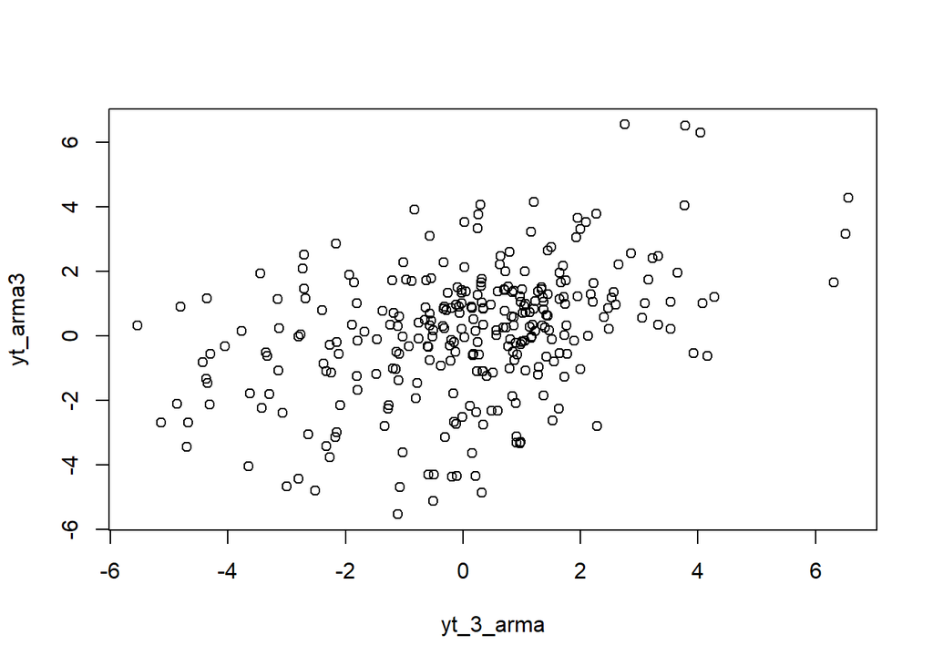

```r
plot(y=yt_arma3,x=yt_3_arma)
```

Berdasarkan scatterplot tersebut, terlihat bahwa terdapat hubungan positif antara Yt dengan Yt−3.

```r
cor(yt_arma3,yt_3_arma)
```

```
## [1] 0.3949067
```